# IE360_Project_RCodes_Group28

Weather and production information is merged and converted to a wide format beforehand in Python. Hours 0, 1, 2, 3, 4, 5, 18, 19, 20, 21, 22, 23 are discarded since their mean production is below 5% of the overall mean. These hours will be predicted as 0 in the forecasting phase. Therefore, we will not build models for these hours.

```r
library(RcppRoll)
library(zoo)
library(scales)
library(corrplot)
library(dplyr)
library(ggcorrplot)
library(GGally)
library(lubridate)
library(forecast)
library(tidyr)
library(data.table)
library(dplyr)
library(ggplot2)
library(stats)
library(fpp)
library(data.table)
library(data.table)
library(lubridate)
library(forecast)
library(repr)
```

#### Since we will make predictions starting from 15th May, data up to 14th April can be used for training.

```r
options(repr.plot.width=12.7, repr.plot.height=8.5)

data_path <- 'filtered_data.csv'

data <- fread(data_path)
colnames(data) <- tolower(colnames(data))
data[, production_target := NULL]
data[, datetime := NULL]
data <- na.omit(data)
tail(data)
str(data)
```

A data.table: 6 × 253

| date <IDate> | hour <int> | csnow_surface_37.75_34.5 <dbl> | csnow_surface_37.75_34.75 <dbl> | csnow_surface_37.75_35.0 <dbl> | csnow_surface_37.75_35.25 <dbl> | csnow_surface_37.75_35.5 <dbl> | csnow_surface_38.0_34.5 <dbl> | csnow_surface_38.0_34.75 <dbl> | csnow_surface_38.0_35.0 <dbl> | ⋯ | uswrf_top_of_atmosphere_38.5_34.75 <dbl> | uswrf_top_of_atmosphere_38.5_35.0 <dbl> | uswrf_top_of_atmosphere_38.5_35.25 <dbl> | uswrf_top_of_atmosphere_38.5_35.5 <dbl> | uswrf_top_of_atmosphere_38.75_34.5 <dbl> | uswrf_top_of_atmosphere_38.75_34.75 <dbl> | uswrf_top_of_atmosphere_38.75_35.0 <dbl> | uswrf_top_of_atmosphere_38.75_35.25 <dbl> | uswrf_top_of_atmosphere_38.75_35.5 <dbl> | production <dbl> |
| --- | --- | --- | --- | --- | --- | --- | --- | --- | --- | --- | --- | --- | --- | --- | --- | --- | --- | --- | --- | --- |
| 2024-04-14 | 12 | 0 | 0 | 0 | 0 | 0 | 0 | 0 | 0 | ⋯ | 219.056 | 321.360 | 236.544 | 498.864 | 194.400 | 212.176 | 247.760 | 375.680 | 485.568 | 7.88 |
| 2024-04-14 | 13 | 0 | 0 | 0 | 0 | 0 | 0 | 0 | 0 | ⋯ | 214.192 | 349.440 | 274.432 | 510.448 | 196.688 | 210.064 | 268.928 | 442.400 | 520.048 | 6.40 |
| 2024-04-14 | 14 | 0 | 0 | 0 | 0 | 0 | 0 | 0 | 0 | ⋯ | 209.904 | 369.168 | 273.872 | 474.736 | 208.512 | 206.912 | 270.208 | 445.296 | 526.720 | 3.14 |
| 2024-04-14 | 15 | 0 | 0 | 0 | 0 | 0 | 0 | 0 | 0 | ⋯ | 204.960 | 339.968 | 266.224 | 482.288 | 219.952 | 203.744 | 257.616 | 448.160 | 547.184 | 3.67 |
| 2024-04-14 | 16 | 0 | 0 | 0 | 0 | 0 | 0 | 0 | 0 | ⋯ | 173.776 | 185.760 | 227.872 | 453.472 | 317.200 | 177.584 | 226.624 | 459.632 | 574.400 | 3.24 |
| 2024-04-14 | 17 | 0 | 0 | 0 | 0 | 0 | 0 | 0 | 0 | ⋯ | 163.504 | 170.432 | 222.640 | 374.880 | 274.288 | 173.712 | 204.720 | 392.576 | 465.680 | 0.71 |

```
Classes 'data.table' and 'data.frame':	10016 obs. of  253 variables:
 $ date                               : IDate, format: "2022-01-01" "2022-01-01" ...
 $ hour                               : int  6 7 8 9 10 11 12 13 14 15 ...
 $ csnow_surface_37.75_34.5           : num  0 0 0 0 0 0 0 0 0 0 ...
 $ csnow_surface_37.75_34.75          : num  0 0 0 0 0 0 0 0 0 0 ...
 $ csnow_surface_37.75_35.0           : num  0 0 0 0 0 0 0 0 0 0 ...
 $ csnow_surface_37.75_35.25          : num  0 0 0 0 0 0 0 0 0 0 ...
 $ csnow_surface_37.75_35.5           : num  0 0 0 0 0 0 0 0 0 0 ...
 $ csnow_surface_38.0_34.5            : num  0 0 0 0 0 0 0 0 0 0 ...
 $ csnow_surface_38.0_34.75           : num  0 0 0 0 0 0 0 0 0 0 ...
 $ csnow_surface_38.0_35.0            : num  0 0 0 0 0 0 0 0 0 0 ...
 $ csnow_surface_38.0_35.25           : num  0 0 0 0 0 0 0 0 0 0 ...
 $ csnow_surface_38.0_35.5            : num  0 0 0 0 0 0 0 0 0 0 ...
 $ csnow_surface_38.25_34.5           : num  0 0 0 0 0 0 0 0 0 0 ...
 $ csnow_surface_38.25_34.75          : num  0 0 0 0 0 0 0 0 0 0 ...
```

[output cut: 87 more lines]

```r
cutoff_date <- as.IDate("2024-01-30")

train_data <- data[date <= cutoff_date]

tail(train_data)
```

A data.table: 6 × 253

| date <IDate> | hour <int> | csnow_surface_37.75_34.5 <dbl> | csnow_surface_37.75_34.75 <dbl> | csnow_surface_37.75_35.0 <dbl> | csnow_surface_37.75_35.25 <dbl> | csnow_surface_37.75_35.5 <dbl> | csnow_surface_38.0_34.5 <dbl> | csnow_surface_38.0_34.75 <dbl> | csnow_surface_38.0_35.0 <dbl> | ⋯ | uswrf_top_of_atmosphere_38.5_34.75 <dbl> | uswrf_top_of_atmosphere_38.5_35.0 <dbl> | uswrf_top_of_atmosphere_38.5_35.25 <dbl> | uswrf_top_of_atmosphere_38.5_35.5 <dbl> | uswrf_top_of_atmosphere_38.75_34.5 <dbl> | uswrf_top_of_atmosphere_38.75_34.75 <dbl> | uswrf_top_of_atmosphere_38.75_35.0 <dbl> | uswrf_top_of_atmosphere_38.75_35.25 <dbl> | uswrf_top_of_atmosphere_38.75_35.5 <dbl> | production <dbl> |
| --- | --- | --- | --- | --- | --- | --- | --- | --- | --- | --- | --- | --- | --- | --- | --- | --- | --- | --- | --- | --- |
| 2024-01-30 | 12 | 0 | 0 | 0 | 1 | 0 | 0 | 0 | 0 | ⋯ | 158.620 | 169.480 | 174.920 | 313.040 | 130.400 | 130.400 | 137.160 | 151.120 | 162.100 | 9.20 |
| 2024-01-30 | 13 | 0 | 0 | 0 | 1 | 0 | 0 | 0 | 0 | ⋯ | 174.360 | 173.040 | 176.840 | 338.820 | 151.320 | 152.320 | 161.620 | 176.140 | 184.040 | 7.49 |
| 2024-01-30 | 14 | 0 | 0 | 1 | 1 | 0 | 0 | 0 | 0 | ⋯ | 168.496 | 169.408 | 174.592 | 351.152 | 158.416 | 157.776 | 163.056 | 172.592 | 176.944 | 3.57 |
| 2024-01-30 | 15 | 0 | 0 | 1 | 1 | 0 | 0 | 0 | 0 | ⋯ | 173.056 | 174.848 | 182.496 | 355.776 | 157.728 | 158.608 | 164.464 | 171.568 | 173.152 | 1.25 |
| 2024-01-30 | 16 | 0 | 0 | 1 | 1 | 0 | 0 | 0 | 0 | ⋯ | 195.120 | 187.008 | 194.688 | 312.080 | 161.280 | 174.432 | 183.104 | 179.136 | 167.808 | 0.21 |
| 2024-01-30 | 17 | 0 | 0 | 1 | 1 | 0 | 0 | 0 | 0 | ⋯ | 172.832 | 163.584 | 170.736 | 260.768 | 154.992 | 161.392 | 159.168 | 155.040 | 142.784 | 0.00 |

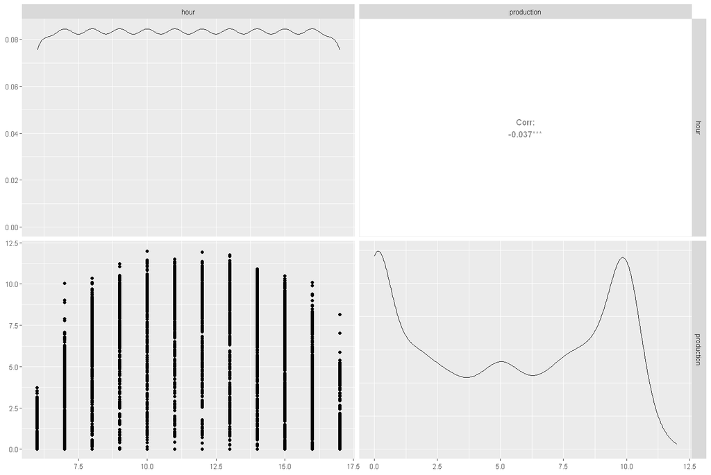

```r
hour_and_prod <- c("hour", "production")
filtered_data_h_vs_prod <- train_data[, ..hour_and_prod, drop = FALSE]

ggpairs(filtered_data_h_vs_prod)
```

Since hour has a nonlinear relationship with production, we transform it to -(hour-12)^2 (the equation of the parabolic shape) and use as a regressor. By doing so, we ensure that the hour column will have maximum values when hour is close to 12.

```r
train_data[, hour_transformed := -(hour - 12)^2]
```

Now, we will add average temperature and lagged values of it as variables. That is because, the effect of temperature may not be instanteneous in real time.

```r
train_data <- as.data.frame(train_data)

tmp_surface_columns <- grep("^tmp_surface", names(train_data), value = TRUE)

# Compute the average of these columns for each row
train_data$avg_tmp <- rowMeans(train_data[, tmp_surface_columns], na.rm = TRUE)

setDT(train_data)
train_data[, avg_temp_lag_1 := shift(avg_tmp, 1)]
train_data[, avg_temp_lag_2 := shift(avg_tmp, 2)]
train_data[, avg_temp_lag_3 := shift(avg_tmp, 3)]

head(train_data)
str(train_data)
```

A data.table: 6 × 258

| date <IDate> | hour <int> | csnow_surface_37.75_34.5 <dbl> | csnow_surface_37.75_34.75 <dbl> | csnow_surface_37.75_35.0 <dbl> | csnow_surface_37.75_35.25 <dbl> | csnow_surface_37.75_35.5 <dbl> | csnow_surface_38.0_34.5 <dbl> | csnow_surface_38.0_34.75 <dbl> | csnow_surface_38.0_35.0 <dbl> | ⋯ | uswrf_top_of_atmosphere_38.75_34.75 <dbl> | uswrf_top_of_atmosphere_38.75_35.0 <dbl> | uswrf_top_of_atmosphere_38.75_35.25 <dbl> | uswrf_top_of_atmosphere_38.75_35.5 <dbl> | production <dbl> | hour_transformed <dbl> | avg_tmp <dbl> | avg_temp_lag_1 <dbl> | avg_temp_lag_2 <dbl> | avg_temp_lag_3 <dbl> |
| --- | --- | --- | --- | --- | --- | --- | --- | --- | --- | --- | --- | --- | --- | --- | --- | --- | --- | --- | --- | --- |
| 2022-01-01 | 6 | 0 | 0 | 0 | 0 | 0 | 0 | 0 | 0 | ⋯ | 0.000 | 0.000 | 0.000 | 0.000 | 0.00 | -36 | 269.035 | NA | NA | NA |
| 2022-01-01 | 7 | 0 | 0 | 0 | 0 | 0 | 0 | 0 | 0 | ⋯ | 0.000 | 0.000 | 0.000 | 0.000 | 0.00 | -25 | 269.001 | 269.035 | NA | NA |
| 2022-01-01 | 8 | 0 | 0 | 0 | 0 | 0 | 0 | 0 | 0 | ⋯ | 0.000 | 0.000 | 0.000 | 0.000 | 3.40 | -16 | 269.002 | 269.001 | 269.035 | NA |
| 2022-01-01 | 9 | 0 | 0 | 0 | 0 | 0 | 0 | 0 | 0 | ⋯ | 8.096 | 8.592 | 8.848 | 8.704 | 6.80 | -9 | 271.634 | 269.002 | 269.001 | 269.035 |
| 2022-01-01 | 10 | 0 | 0 | 0 | 0 | 0 | 0 | 0 | 0 | ⋯ | 105.264 | 120.656 | 137.664 | 142.336 | 9.38 | -4 | 275.786 | 271.634 | 269.002 | 269.001 |
| 2022-01-01 | 11 | 0 | 0 | 0 | 0 | 0 | 0 | 0 | 0 | ⋯ | 127.472 | 130.512 | 142.112 | 147.088 | 7.65 | -1 | 278.553 | 275.786 | 271.634 | 269.002 |

```
Classes 'data.table' and 'data.frame':	9116 obs. of  258 variables:
 $ date                               : IDate, format: "2022-01-01" "2022-01-01" ...
 $ hour                               : int  6 7 8 9 10 11 12 13 14 15 ...
 $ csnow_surface_37.75_34.5           : num  0 0 0 0 0 0 0 0 0 0 ...
 $ csnow_surface_37.75_34.75          : num  0 0 0 0 0 0 0 0 0 0 ...
 $ csnow_surface_37.75_35.0           : num  0 0 0 0 0 0 0 0 0 0 ...
 $ csnow_surface_37.75_35.25          : num  0 0 0 0 0 0 0 0 0 0 ...
 $ csnow_surface_37.75_35.5           : num  0 0 0 0 0 0 0 0 0 0 ...
 $ csnow_surface_38.0_34.5            : num  0 0 0 0 0 0 0 0 0 0 ...
 $ csnow_surface_38.0_34.75           : num  0 0 0 0 0 0 0 0 0 0 ...
 $ csnow_surface_38.0_35.0            : num  0 0 0 0 0 0 0 0 0 0 ...
 $ csnow_surface_38.0_35.25           : num  0 0 0 0 0 0 0 0 0 0 ...
 $ csnow_surface_38.0_35.5            : num  0 0 0 0 0 0 0 0 0 0 ...
 $ csnow_surface_38.25_34.5           : num  0 0 0 0 0 0 0 0 0 0 ...
 $ csnow_surface_38.25_34.75          : num  0 0 0 0 0 0 0 0 0 0 ...
```

[output cut: 87 more lines]

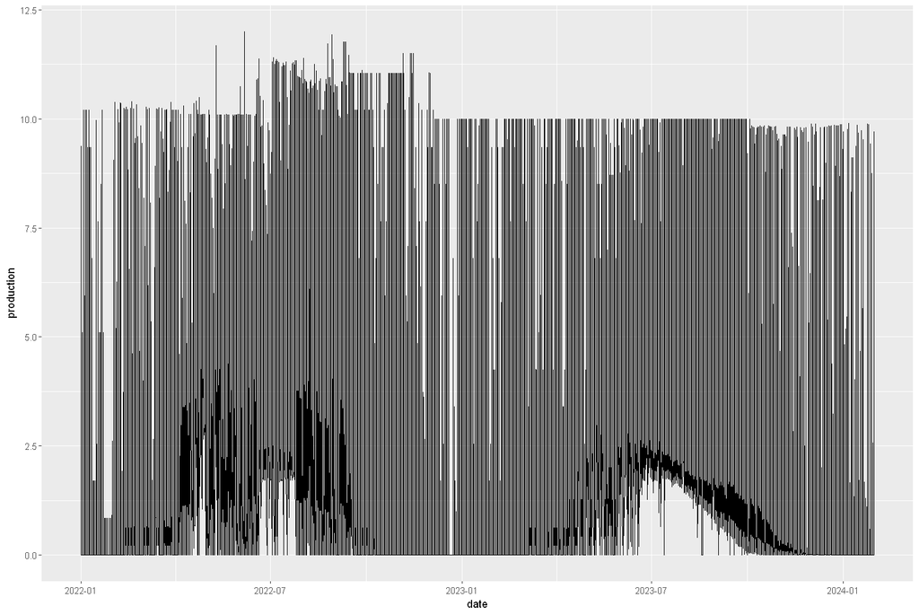

```r
require(ggplot2)

ggplot(train_data, aes(x = date, y = production)) + geom_line()
```

From the ggplot, we acknowledge that there is a maximum production level around 10 generally. Therefore, we also add another variable for maximum production, which will include the max production level for the last 3 days.

```r
train_data$max_production <- sapply(1:nrow(train_data), function(i) {
  max_production <- ifelse(i <= 36, max(train_data$production[1:i]), max(train_data$production[(i - 35):i]))
  return(max_production)
})

head(train_data)
str(train_data)
```

A data.table: 6 × 259

| date <IDate> | hour <int> | csnow_surface_37.75_34.5 <dbl> | csnow_surface_37.75_34.75 <dbl> | csnow_surface_37.75_35.0 <dbl> | csnow_surface_37.75_35.25 <dbl> | csnow_surface_37.75_35.5 <dbl> | csnow_surface_38.0_34.5 <dbl> | csnow_surface_38.0_34.75 <dbl> | csnow_surface_38.0_35.0 <dbl> | ⋯ | uswrf_top_of_atmosphere_38.75_35.0 <dbl> | uswrf_top_of_atmosphere_38.75_35.25 <dbl> | uswrf_top_of_atmosphere_38.75_35.5 <dbl> | production <dbl> | hour_transformed <dbl> | avg_tmp <dbl> | avg_temp_lag_1 <dbl> | avg_temp_lag_2 <dbl> | avg_temp_lag_3 <dbl> | max_production <dbl> |
| --- | --- | --- | --- | --- | --- | --- | --- | --- | --- | --- | --- | --- | --- | --- | --- | --- | --- | --- | --- | --- |
| 2022-01-01 | 6 | 0 | 0 | 0 | 0 | 0 | 0 | 0 | 0 | ⋯ | 0.000 | 0.000 | 0.000 | 0.00 | -36 | 269.035 | NA | NA | NA | 0.00 |
| 2022-01-01 | 7 | 0 | 0 | 0 | 0 | 0 | 0 | 0 | 0 | ⋯ | 0.000 | 0.000 | 0.000 | 0.00 | -25 | 269.001 | 269.035 | NA | NA | 0.00 |
| 2022-01-01 | 8 | 0 | 0 | 0 | 0 | 0 | 0 | 0 | 0 | ⋯ | 0.000 | 0.000 | 0.000 | 3.40 | -16 | 269.002 | 269.001 | 269.035 | NA | 3.40 |
| 2022-01-01 | 9 | 0 | 0 | 0 | 0 | 0 | 0 | 0 | 0 | ⋯ | 8.592 | 8.848 | 8.704 | 6.80 | -9 | 271.634 | 269.002 | 269.001 | 269.035 | 6.80 |
| 2022-01-01 | 10 | 0 | 0 | 0 | 0 | 0 | 0 | 0 | 0 | ⋯ | 120.656 | 137.664 | 142.336 | 9.38 | -4 | 275.786 | 271.634 | 269.002 | 269.001 | 9.38 |
| 2022-01-01 | 11 | 0 | 0 | 0 | 0 | 0 | 0 | 0 | 0 | ⋯ | 130.512 | 142.112 | 147.088 | 7.65 | -1 | 278.553 | 275.786 | 271.634 | 269.002 | 9.38 |

```
Classes 'data.table' and 'data.frame':	9116 obs. of  259 variables:
 $ date                               : IDate, format: "2022-01-01" "2022-01-01" ...
 $ hour                               : int  6 7 8 9 10 11 12 13 14 15 ...
 $ csnow_surface_37.75_34.5           : num  0 0 0 0 0 0 0 0 0 0 ...
 $ csnow_surface_37.75_34.75          : num  0 0 0 0 0 0 0 0 0 0 ...
 $ csnow_surface_37.75_35.0           : num  0 0 0 0 0 0 0 0 0 0 ...
 $ csnow_surface_37.75_35.25          : num  0 0 0 0 0 0 0 0 0 0 ...
 $ csnow_surface_37.75_35.5           : num  0 0 0 0 0 0 0 0 0 0 ...
 $ csnow_surface_38.0_34.5            : num  0 0 0 0 0 0 0 0 0 0 ...
 $ csnow_surface_38.0_34.75           : num  0 0 0 0 0 0 0 0 0 0 ...
 $ csnow_surface_38.0_35.0            : num  0 0 0 0 0 0 0 0 0 0 ...
 $ csnow_surface_38.0_35.25           : num  0 0 0 0 0 0 0 0 0 0 ...
 $ csnow_surface_38.0_35.5            : num  0 0 0 0 0 0 0 0 0 0 ...
 $ csnow_surface_38.25_34.5           : num  0 0 0 0 0 0 0 0 0 0 ...
 $ csnow_surface_38.25_34.75          : num  0 0 0 0 0 0 0 0 0 0 ...
```

[output cut: 87 more lines]

```r
data_path <- 'new_data_16may.csv'

test_data <- fread(data_path)
colnames(test_data) <- tolower(colnames(test_data))

cutoff_date <- as.IDate("2024-01-30")
test_data <- test_data[date > cutoff_date]

test_data <- na.omit(test_data)
test_data[, hour_transformed := -(hour - 12)^2]
test_data <- as.data.frame(test_data)

test_data$max_production <- sapply(1:nrow(test_data), function(i) {
  max_production <- ifelse(i <= 36, max(test_data$production[1:i]), max(test_data$production[(i - 35):i]))
  return(max_production)
})

tmp_surface_columns <- grep("^tmp_surface", names(test_data), value = TRUE)

# Compute the average of these columns for each row
test_data$avg_tmp <- rowMeans(test_data[, tmp_surface_columns], na.rm = TRUE)

setDT(test_data)
test_data[, avg_temp_lag_1 := shift(avg_tmp, 1)]
test_data[, avg_temp_lag_2 := shift(avg_tmp, 2)]
test_data[, avg_temp_lag_3 := shift(avg_tmp, 3)]


head(test_data)
str(test_data)
```

A data.table: 6 × 259

| date <IDate> | hour <int> | csnow_surface_37.75_34.5 <dbl> | csnow_surface_37.75_34.75 <dbl> | csnow_surface_37.75_35.0 <dbl> | csnow_surface_37.75_35.25 <dbl> | csnow_surface_37.75_35.5 <dbl> | csnow_surface_38.0_34.5 <dbl> | csnow_surface_38.0_34.75 <dbl> | csnow_surface_38.0_35.0 <dbl> | ⋯ | uswrf_top_of_atmosphere_38.75_35.0 <dbl> | uswrf_top_of_atmosphere_38.75_35.25 <dbl> | uswrf_top_of_atmosphere_38.75_35.5 <dbl> | production <dbl> | hour_transformed <dbl> | max_production <dbl> | avg_tmp <dbl> | avg_temp_lag_1 <dbl> | avg_temp_lag_2 <dbl> | avg_temp_lag_3 <dbl> |
| --- | --- | --- | --- | --- | --- | --- | --- | --- | --- | --- | --- | --- | --- | --- | --- | --- | --- | --- | --- | --- |
| 2024-01-31 | 6 | 0 | 0 | 0 | 1 | 0 | 0 | 0 | 0 | ⋯ | 0.000 | 0.000 | 0.000 | 0.01 | -36 | 0.01 | 268.541 | NA | NA | NA |
| 2024-01-31 | 7 | 0 | 0 | 0 | 1 | 0 | 0 | 0 | 0 | ⋯ | 0.000 | 0.000 | 0.000 | 0.79 | -25 | 0.79 | 268.478 | 268.541 | NA | NA |
| 2024-01-31 | 8 | 0 | 0 | 0 | 1 | 1 | 0 | 0 | 0 | ⋯ | 0.176 | 0.208 | 0.256 | 5.60 | -16 | 5.60 | 268.843 | 268.478 | 268.541 | NA |
| 2024-01-31 | 9 | 0 | 0 | 0 | 1 | 1 | 0 | 0 | 0 | ⋯ | 9.952 | 10.704 | 9.728 | 8.86 | -9 | 8.86 | 271.236 | 268.843 | 268.478 | 268.541 |
| 2024-01-31 | 10 | 0 | 0 | 1 | 1 | 1 | 0 | 0 | 0 | ⋯ | 130.120 | 123.900 | 102.560 | 9.89 | -4 | 9.89 | 274.211 | 271.236 | 268.843 | 268.478 |
| 2024-01-31 | 11 | 0 | 0 | 1 | 1 | 1 | 0 | 0 | 0 | ⋯ | 164.500 | 135.880 | 114.740 | 9.85 | -1 | 9.89 | 276.570 | 274.211 | 271.236 | 268.843 |

```
Classes 'data.table' and 'data.frame':	1272 obs. of  259 variables:
 $ date                               : IDate, format: "2024-01-31" "2024-01-31" ...
 $ hour                               : int  6 7 8 9 10 11 12 13 14 15 ...
 $ csnow_surface_37.75_34.5           : num  0 0 0 0 0 0 0 0 0 0 ...
 $ csnow_surface_37.75_34.75          : num  0 0 0 0 0 0 0 0 1 1 ...
 $ csnow_surface_37.75_35.0           : num  0 0 0 0 1 1 1 1 1 1 ...
 $ csnow_surface_37.75_35.25          : num  1 1 1 1 1 1 1 1 1 1 ...
 $ csnow_surface_37.75_35.5           : num  0 0 1 1 1 1 1 1 1 1 ...
 $ csnow_surface_38.0_34.5            : num  0 0 0 0 0 0 0 0 0 0 ...
 $ csnow_surface_38.0_34.75           : num  0 0 0 0 0 0 0 0 0 0 ...
 $ csnow_surface_38.0_35.0            : num  0 0 0 0 0 0 0 0 0 1 ...
 $ csnow_surface_38.0_35.25           : num  0 0 0 1 1 1 1 1 1 1 ...
 $ csnow_surface_38.0_35.5            : num  0 0 1 1 1 1 1 1 1 1 ...
 $ csnow_surface_38.25_34.5           : num  0 0 0 0 0 0 0 0 0 0 ...
 $ csnow_surface_38.25_34.75          : num  0 0 0 0 0 0 0 0 0 0 ...
```

[output cut: 87 more lines]

```r
#reporting accuracy
accu=function(name,actual,forecast){
  model = name
  n=length(actual)
  error=actual-forecast
  mean=mean(actual)
  sd=sd(actual)
  CV=sd/mean
  FBias=sum(error)/sum(actual)
  MAPE=sum(abs(error/(actual+0.00001)))/n
  RMSE=sqrt(sum(error^2)/n)
  MAD=sum(abs(error))/n
  MADP=sum(abs(error))/sum(abs(actual))
  WMAPE=MAD/mean
  l=data.frame(model,n,mean,sd,CV,FBias,MAPE,RMSE,MAD,MADP,WMAPE)
  return(l)
}
```

# Baseline : Time Series Regression with All Variables

We will build a time series linear regression model using all variables. This model will be our baseline. In the test phase, we will replace negative predicted values with zero, since production cannot be negative.

```r
train_data <- as.data.frame(train_data)
feature_columns <- setdiff(names(train_data), c('date', 'hour', 'production','avg_tmp'))

X <- train_data[, feature_columns, drop = FALSE]
y <- train_data$production

model <- lm(production ~ ., data = train_data[, c(feature_columns, "production")])

summary(model)
```

```
Call:
lm(formula = production ~ ., data = train_data[, c(feature_columns,
    "production")])

Residuals:
    Min      1Q  Median      3Q     Max
-9.0491 -1.2017  0.1399  1.3061  7.8945

Coefficients:
                                      Estimate Std. Error t value Pr(>|t|)
(Intercept)                         -2.540e+01  2.064e+00 -12.303  < 2e-16 ***
csnow_surface_37.75_34.5             1.123e-01  1.861e-01   0.603 0.546341
csnow_surface_37.75_34.75            3.871e-03  1.615e-01   0.024 0.980874
csnow_surface_37.75_35.0            -1.464e-02  1.398e-01  -0.105 0.916611
csnow_surface_37.75_35.25           -1.050e-01  1.185e-01  -0.886 0.375709
csnow_surface_37.75_35.5             2.874e-01  1.650e-01   1.742 0.081603 .
csnow_surface_38.0_34.5             -5.720e-01  1.574e-01  -3.635 0.000280 ***
csnow_surface_38.0_34.75            -9.924e-03  1.838e-01  -0.054 0.956948
csnow_surface_38.0_35.0              3.194e-01  1.630e-01   1.959 0.050148 .
csnow_surface_38.0_35.25            -1.260e-01  1.443e-01  -0.873 0.382431
csnow_surface_38.0_35.5              4.884e-02  1.533e-01   0.319 0.750002
csnow_surface_38.25_34.5             4.952e-02  1.808e-01   0.274 0.784213
csnow_surface_38.25_34.75            2.384e-02  2.171e-01   0.110 0.912554
csnow_surface_38.25_35.0            -7.208e-02  2.232e-01  -0.323 0.746722
csnow_surface_38.25_35.25            1.989e-01  2.254e-01   0.882 0.377733
csnow_surface_38.25_35.5            -1.290e-01  1.827e-01  -0.706 0.480191
csnow_surface_38.5_34.5              6.504e-01  2.065e-01   3.149 0.001642 **
csnow_surface_38.5_34.75             1.337e-01  2.163e-01   0.618 0.536304
csnow_surface_38.5_35.0             -4.069e-01  2.231e-01  -1.824 0.068148 .
csnow_surface_38.5_35.25            -4.325e-01  1.894e-01  -2.284 0.022405 *
csnow_surface_38.5_35.5              2.850e-01  1.298e-01   2.196 0.028150 *
csnow_surface_38.75_34.5            -1.629e-01  2.137e-01  -0.762 0.446033
csnow_surface_38.75_34.75           -7.728e-02  2.672e-01  -0.289 0.772425
csnow_surface_38.75_35.0            -4.558e-02  3.021e-01  -0.151 0.880067
csnow_surface_38.75_35.25           -3.715e-01  2.879e-01  -1.290 0.197062
csnow_surface_38.75_35.5            -1.747e-01  2.256e-01  -0.774 0.438746
dlwrf_surface_37.75_34.5            -2.569e-02  5.116e-03  -5.022 5.23e-07 ***
dlwrf_surface_37.75_34.75            1.263e-02  5.899e-03   2.141 0.032327 *
dlwrf_surface_37.75_35.0             6.762e-03  5.285e-03   1.279 0.200801
dlwrf_surface_37.75_35.25           -1.698e-02  4.252e-03  -3.995 6.52e-05 ***
```

[output cut: 218 more lines]

```
uswrf_top_of_atmosphere_38.75_35.0   2.169e-02  1.641e-02   1.321 0.186427
uswrf_top_of_atmosphere_38.75_35.25 -2.937e-02  1.479e-02  -1.986 0.047070 *
uswrf_top_of_atmosphere_38.75_35.5   5.444e-02  9.517e-03   5.720 1.10e-08 ***
hour_transformed                     1.129e-01  5.156e-03  21.904  < 2e-16 ***
avg_temp_lag_1                      -6.388e-02  8.533e-03  -7.486 7.79e-14 ***
avg_temp_lag_2                      -5.468e-02  8.483e-03  -6.446 1.21e-10 ***
avg_temp_lag_3                      -2.940e-02  6.286e-03  -4.677 2.95e-06 ***
max_production                       3.086e-01  1.945e-02  15.865  < 2e-16 ***
---
Signif. codes:  0 '***' 0.001 '**' 0.01 '*' 0.05 '.' 0.1 ' ' 1

Residual standard error: 1.945 on 8857 degrees of freedom
  (3 observations deleted due to missingness)
Multiple R-squared:  0.7466,	Adjusted R-squared:  0.7393
F-statistic: 102.3 on 255 and 8857 DF,  p-value: < 2.2e-16
```

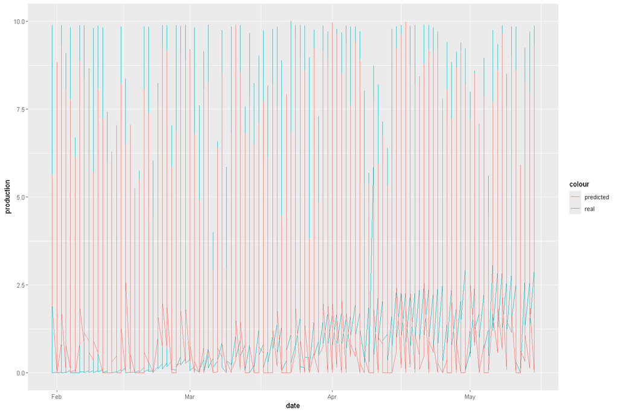

```
	Ljung-Box test

data:  Residuals
Q* = 675.43, df = 10, p-value < 2.2e-16

Model df: 0.   Total lags used: 10
```

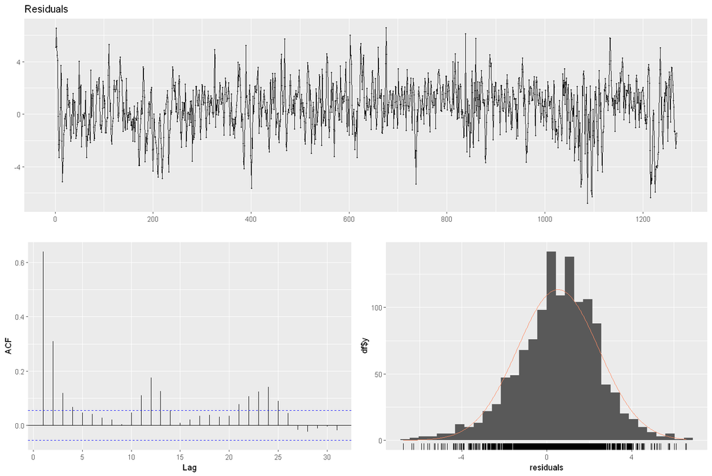

```r
test_data <- as.data.frame(test_data)
baseline_evaluation <- copy(test_data)
baseline_evaluation <- na.omit(baseline_evaluation)
setDT(baseline_evaluation)
baseline_evaluation[,predicted:=predict(model,baseline_evaluation)]

# Replace negative values with zero
baseline_evaluation[, predicted := ifelse(predicted < 0, 0, predicted)]
baseline_evaluation[,residual:=production-predicted]

ggplot(baseline_evaluation,aes(x=date)) + geom_line(aes(y=production,color='real')) + geom_line(aes(y=predicted,color='predicted'))
checkresiduals(baseline_evaluation$residual)
```

```r
comparisons <- accu("0. Baseline-LM", baseline_evaluation$production, baseline_evaluation$predicted)
comparisons
```

A data.frame: 1 × 11

| model <chr> | n <int> | mean <dbl> | sd <dbl> | CV <dbl> | FBias <dbl> | MAPE <dbl> | RMSE <dbl> | MAD <dbl> | MADP <dbl> | WMAPE <dbl> |
| --- | --- | --- | --- | --- | --- | --- | --- | --- | --- | --- |
| 0. Baseline-LM | 1269 | 5.060165 | 3.38983 | 0.6699049 | 0.1048255 | 4469.314 | 1.993499 | 1.564115 | 0.3091036 | 0.3091036 |

## Lasso Regression for Eliminating Least Effective Variables

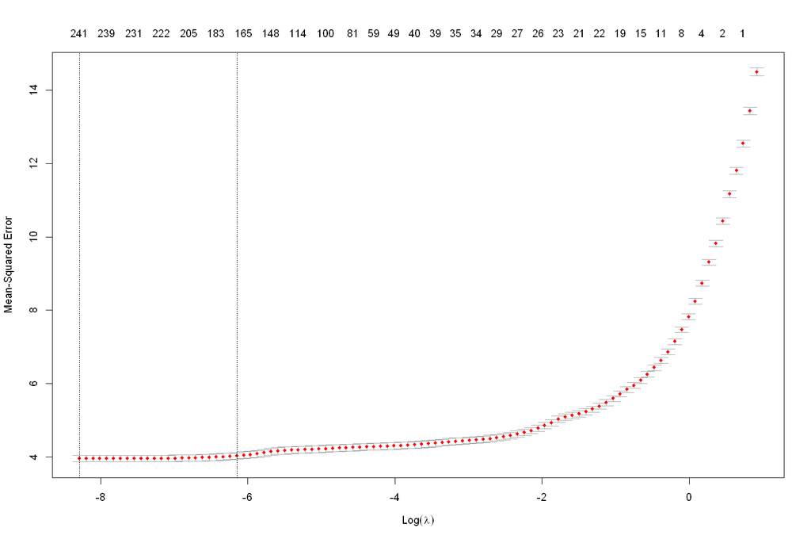

```r
library(glmnet)

llm <- copy(train_data)
llm <- na.omit(llm)
setDT(llm)

# Define the columns -rather than hour, production, and date- to standardize
columns_to_standardize <- setdiff(names(llm), c("hour", "production", "date"))

# Standardize the columns
llm[, (columns_to_standardize) := lapply(.SD, scale), .SDcols = columns_to_standardize]

llm <- as.data.frame(llm)

predictors <- subset(llm, select = -c(date, production, hour))
response <- llm$production


# Perform cross-validation to find the optimal lambda value
cv_fit <- cv.glmnet(as.matrix(predictors), response, alpha = 1)

# Plot the cross-validated mean squared error (MSE) vs. lambda
plot(cv_fit)
```

The minimum MSE is found when model complexity is the highest. Therefore, we will use the lambda that is within one standard deviation of the minimum MSE.

```r
# Find the lambda value within one standard error of the minimum MSE
lambda_1se <- cv_fit$lambda.1se

# Use the selected lambda value to fit the final Lasso regression model
lasso_model_1 <- glmnet(as.matrix(predictors), response, alpha = 1, lambda = lambda_1se)

print(lasso_model_1)

coefficients <- coef(lasso_model_1, s = lambda_1se <- cv_fit$lambda.1se)
coefficients <- as.matrix(coef(lasso_model_1, s = lambda_1se))

selected_variables <- rownames(coefficients)[coefficients[, 1] != 0]

print(selected_variables)
```

```
Call:  glmnet(x = as.matrix(predictors), y = response, alpha = 1, lambda = lambda_1se)

   Df  %Dev   Lambda
1 175 73.55 0.002137
  [1] "(Intercept)"
  [2] "csnow_surface_37.75_34.5"
  [3] "csnow_surface_37.75_34.75"
  [4] "csnow_surface_37.75_35.25"
  [5] "csnow_surface_37.75_35.5"
  [6] "csnow_surface_38.0_34.5"
  [7] "csnow_surface_38.0_34.75"
  [8] "csnow_surface_38.0_35.0"
  [9] "csnow_surface_38.0_35.25"
 [10] "csnow_surface_38.0_35.5"
 [11] "csnow_surface_38.25_34.5"
```

[output cut: 165 more lines]

Filter the data frame by keeping only the variables that Lasso Regression selected

```r
selected_variables <- selected_variables[selected_variables != "(Intercept)"]

columns_to_keep <- c("date", "hour", "production", selected_variables)

train_data <- as.data.frame(train_data)

filtered_data <- train_data[, columns_to_keep, drop = FALSE]

head(filtered_data)
str(filtered_data)
```

A data.frame: 6 × 178

|  | date <IDate> | hour <int> | production <dbl> | csnow_surface_37.75_34.5 <dbl> | csnow_surface_37.75_34.75 <dbl> | csnow_surface_37.75_35.25 <dbl> | csnow_surface_37.75_35.5 <dbl> | csnow_surface_38.0_34.5 <dbl> | csnow_surface_38.0_34.75 <dbl> | csnow_surface_38.0_35.0 <dbl> | ⋯ | uswrf_top_of_atmosphere_38.5_34.75 <dbl> | uswrf_top_of_atmosphere_38.5_35.0 <dbl> | uswrf_top_of_atmosphere_38.5_35.5 <dbl> | uswrf_top_of_atmosphere_38.75_34.5 <dbl> | uswrf_top_of_atmosphere_38.75_35.5 <dbl> | hour_transformed <dbl> | avg_temp_lag_1 <dbl> | avg_temp_lag_2 <dbl> | avg_temp_lag_3 <dbl> | max_production <dbl> |
| --- | --- | --- | --- | --- | --- | --- | --- | --- | --- | --- | --- | --- | --- | --- | --- | --- | --- | --- | --- | --- | --- |
| 1 | 2022-01-01 | 6 | 0.00 | 0 | 0 | 0 | 0 | 0 | 0 | 0 | ⋯ | 0.000 | 0.000 | 0.000 | 0.000 | 0.000 | -36 | NA | NA | NA | 0.00 |
| 2 | 2022-01-01 | 7 | 0.00 | 0 | 0 | 0 | 0 | 0 | 0 | 0 | ⋯ | 0.000 | 0.000 | 0.000 | 0.000 | 0.000 | -25 | 269.035 | NA | NA | 0.00 |
| 3 | 2022-01-01 | 8 | 3.40 | 0 | 0 | 0 | 0 | 0 | 0 | 0 | ⋯ | 0.000 | 0.000 | 0.000 | 0.000 | 0.000 | -16 | 269.001 | 269.035 | NA | 3.40 |
| 4 | 2022-01-01 | 9 | 6.80 | 0 | 0 | 0 | 0 | 0 | 0 | 0 | ⋯ | 8.368 | 8.704 | 12.080 | 7.536 | 8.704 | -9 | 269.002 | 269.001 | 269.035 | 6.80 |
| 5 | 2022-01-01 | 10 | 9.38 | 0 | 0 | 0 | 0 | 0 | 0 | 0 | ⋯ | 102.752 | 120.864 | 199.200 | 104.464 | 142.336 | -4 | 271.634 | 269.002 | 269.001 | 9.38 |
| 6 | 2022-01-01 | 11 | 7.65 | 0 | 0 | 0 | 0 | 0 | 0 | 0 | ⋯ | 116.944 | 123.584 | 234.032 | 140.640 | 147.088 | -1 | 275.786 | 271.634 | 269.002 | 9.38 |

```
'data.frame':	9116 obs. of  178 variables:
 $ date                               : IDate, format: "2022-01-01" "2022-01-01" ...
 $ hour                               : int  6 7 8 9 10 11 12 13 14 15 ...
 $ production                         : num  0 0 3.4 6.8 9.38 7.65 6.8 5.1 5.1 1.7 ...
 $ csnow_surface_37.75_34.5           : num  0 0 0 0 0 0 0 0 0 0 ...
 $ csnow_surface_37.75_34.75          : num  0 0 0 0 0 0 0 0 0 0 ...
 $ csnow_surface_37.75_35.25          : num  0 0 0 0 0 0 0 0 0 0 ...
 $ csnow_surface_37.75_35.5           : num  0 0 0 0 0 0 0 0 0 0 ...
 $ csnow_surface_38.0_34.5            : num  0 0 0 0 0 0 0 0 0 0 ...
 $ csnow_surface_38.0_34.75           : num  0 0 0 0 0 0 0 0 0 0 ...
 $ csnow_surface_38.0_35.0            : num  0 0 0 0 0 0 0 0 0 0 ...
 $ csnow_surface_38.0_35.25           : num  0 0 0 0 0 0 0 0 0 0 ...
 $ csnow_surface_38.0_35.5            : num  0 0 0 0 0 0 0 0 0 0 ...
 $ csnow_surface_38.25_34.5           : num  0 0 0 0 0 0 0 0 0 0 ...
 $ csnow_surface_38.25_34.75          : num  0 0 0 0 0 0 0 0 0 0 ...
```

[output cut: 86 more lines]

## First Approach : Linear Regression with Lasso Variables + Transformed Hour

```r
feature_columns <- setdiff(names(filtered_data), c('date', 'hour', 'production'))

X <- filtered_data[, feature_columns, drop = FALSE]
y <- filtered_data$production

model <- lm(production ~ ., data = filtered_data[, c(feature_columns, "production")])

summary(model)
```

```
Call:
lm(formula = production ~ ., data = filtered_data[, c(feature_columns,
    "production")])

Residuals:
    Min      1Q  Median      3Q     Max
-8.9275 -1.1780  0.1456  1.3219  7.5304

Coefficients:
                                      Estimate Std. Error t value Pr(>|t|)
(Intercept)                         -2.588e+01  1.947e+00 -13.294  < 2e-16 ***
csnow_surface_37.75_34.5             1.562e-01  1.815e-01   0.860 0.389638
csnow_surface_37.75_34.75           -2.624e-02  1.547e-01  -0.170 0.865269
csnow_surface_37.75_35.25           -1.164e-01  1.119e-01  -1.040 0.298183
csnow_surface_37.75_35.5             2.883e-01  1.576e-01   1.830 0.067339 .
csnow_surface_38.0_34.5             -4.996e-01  1.515e-01  -3.298 0.000978 ***
csnow_surface_38.0_34.75            -1.288e-01  1.786e-01  -0.721 0.470894
csnow_surface_38.0_35.0              3.186e-01  1.567e-01   2.033 0.042042 *
csnow_surface_38.0_35.25            -1.281e-01  1.295e-01  -0.989 0.322457
csnow_surface_38.0_35.5              7.574e-02  1.480e-01   0.512 0.608923
csnow_surface_38.25_34.5             1.362e-01  1.753e-01   0.777 0.437177
csnow_surface_38.25_34.75            7.500e-02  2.124e-01   0.353 0.723974
csnow_surface_38.25_35.0            -6.450e-02  2.195e-01  -0.294 0.768863
csnow_surface_38.25_35.25            1.284e-01  2.178e-01   0.590 0.555478
csnow_surface_38.25_35.5            -1.096e-01  1.746e-01  -0.628 0.530323
csnow_surface_38.5_34.5              6.201e-01  2.030e-01   3.055 0.002258 **
csnow_surface_38.5_34.75             9.175e-02  2.120e-01   0.433 0.665237
csnow_surface_38.5_35.0             -4.003e-01  2.197e-01  -1.822 0.068478 .
csnow_surface_38.5_35.25            -3.508e-01  1.832e-01  -1.916 0.055457 .
csnow_surface_38.5_35.5              2.846e-01  1.266e-01   2.247 0.024648 *
csnow_surface_38.75_34.5            -1.670e-01  2.081e-01  -0.803 0.422123
csnow_surface_38.75_34.75           -1.178e-01  2.619e-01  -0.450 0.653024
csnow_surface_38.75_35.0            -7.741e-02  2.944e-01  -0.263 0.792597
csnow_surface_38.75_35.25           -2.894e-01  2.832e-01  -1.022 0.306974
csnow_surface_38.75_35.5            -2.550e-01  2.197e-01  -1.161 0.245801
dlwrf_surface_37.75_34.5            -2.434e-02  4.586e-03  -5.308 1.14e-07 ***
dlwrf_surface_37.75_34.75            1.072e-02  5.318e-03   2.016 0.043806 *
dlwrf_surface_37.75_35.0             6.974e-03  4.636e-03   1.504 0.132560
dlwrf_surface_37.75_35.25           -1.445e-02  3.347e-03  -4.318 1.59e-05 ***
dlwrf_surface_38.25_34.75           -1.151e-02  4.311e-03  -2.671 0.007585 **
```

[output cut: 138 more lines]

```
uswrf_top_of_atmosphere_38.5_35.5    2.668e-02  5.483e-03   4.865 1.16e-06 ***
uswrf_top_of_atmosphere_38.75_34.5  -4.145e-03  9.035e-04  -4.587 4.55e-06 ***
uswrf_top_of_atmosphere_38.75_35.5   4.496e-02  5.013e-03   8.970  < 2e-16 ***
hour_transformed                     1.212e-01  4.679e-03  25.900  < 2e-16 ***
avg_temp_lag_1                      -6.083e-02  8.466e-03  -7.185 7.28e-13 ***
avg_temp_lag_2                      -5.214e-02  8.444e-03  -6.174 6.93e-10 ***
avg_temp_lag_3                      -2.737e-02  6.181e-03  -4.427 9.67e-06 ***
max_production                       3.116e-01  1.906e-02  16.346  < 2e-16 ***
---
Signif. codes:  0 '***' 0.001 '**' 0.01 '*' 0.05 '.' 0.1 ' ' 1

Residual standard error: 1.952 on 8937 degrees of freedom
  (3 observations deleted due to missingness)
Multiple R-squared:  0.7424,	Adjusted R-squared:  0.7374
F-statistic: 147.2 on 175 and 8937 DF,  p-value: < 2.2e-16
```

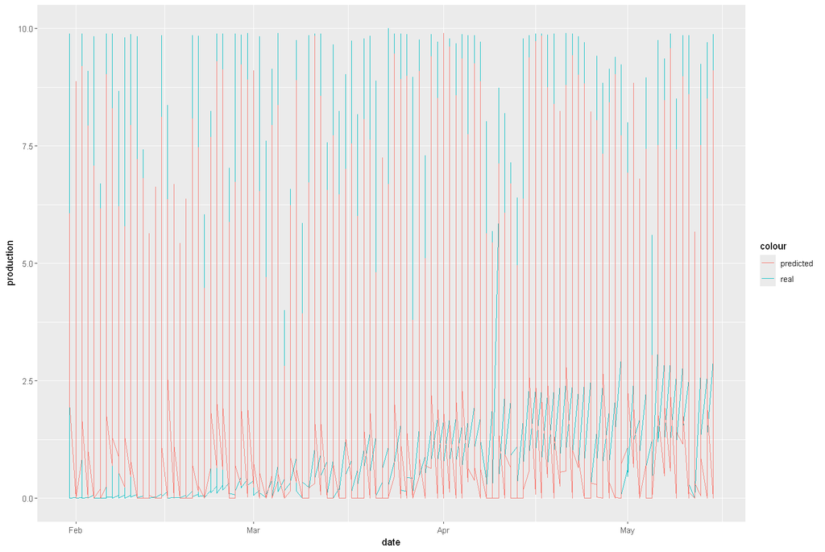

```
	Ljung-Box test

data:  Residuals
Q* = 650.1, df = 10, p-value < 2.2e-16

Model df: 0.   Total lags used: 10
```

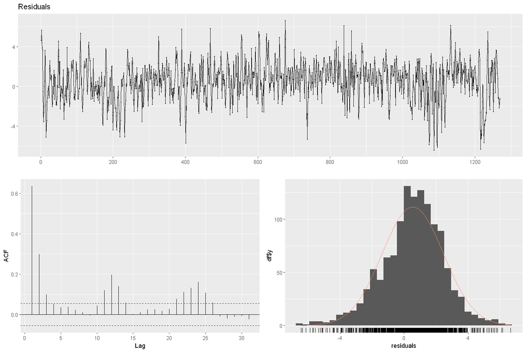

```r
test_data <- as.data.frame(test_data)
first_model_evaluation <- test_data[, columns_to_keep, drop = FALSE]
first_model_evaluation <- na.omit(first_model_evaluation)
setDT(first_model_evaluation)

first_model_evaluation[,predicted:=predict(model,first_model_evaluation)]
# Replace negative values with zero
first_model_evaluation[, predicted := ifelse(predicted < 0, 0, predicted)]
first_model_evaluation[,residual:=production-predicted]

ggplot(first_model_evaluation,aes(x=date)) + geom_line(aes(y=production,color='real')) + geom_line(aes(y=predicted,color='predicted'))
checkresiduals(first_model_evaluation$residual)
```

Although residual series look like white noise, ACF of residuals has a seasonal pattern which indicates there is a seasonality information that is not explained. The histogram look like a normal distribution but indicates that we are underpredicting. The underprediction pattern can be also seen from the predicted vs real ggplot.

```r
accu1 <- accu("1. Lasso(1sd)-LM", first_model_evaluation$production, first_model_evaluation$predicted)
comparisons <- rbind(comparisons, accu1)
comparisons
```

A data.frame: 2 × 11

| model <chr> | n <int> | mean <dbl> | sd <dbl> | CV <dbl> | FBias <dbl> | MAPE <dbl> | RMSE <dbl> | MAD <dbl> | MADP <dbl> | WMAPE <dbl> |
| --- | --- | --- | --- | --- | --- | --- | --- | --- | --- | --- |
| 0. Baseline-LM | 1269 | 5.060165 | 3.38983 | 0.6699049 | 0.1048255 | 4469.314 | 1.993499 | 1.564115 | 0.3091036 | 0.3091036 |
| 1. Lasso(1sd)-LM | 1269 | 5.060165 | 3.38983 | 0.6699049 | 0.1088095 | 4058.146 | 1.994581 | 1.573241 | 0.3109070 | 0.3109070 |

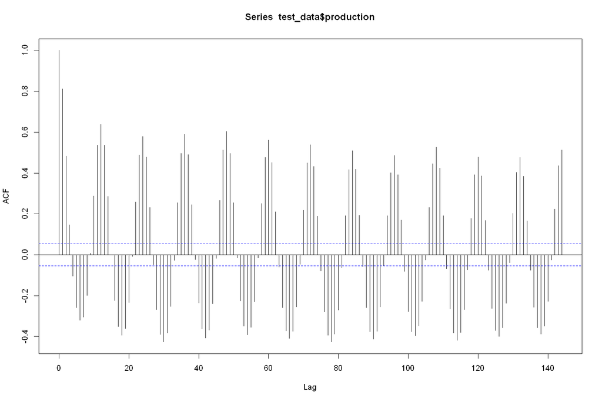

```r
acf(test_data$production, lag.max=144)
```

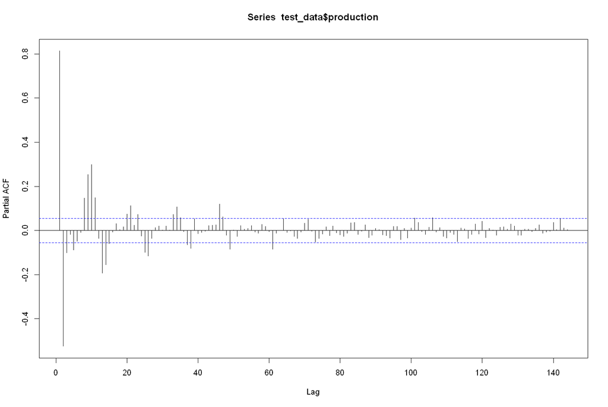

```r
pacf(test_data$production, lag.max=144)
```

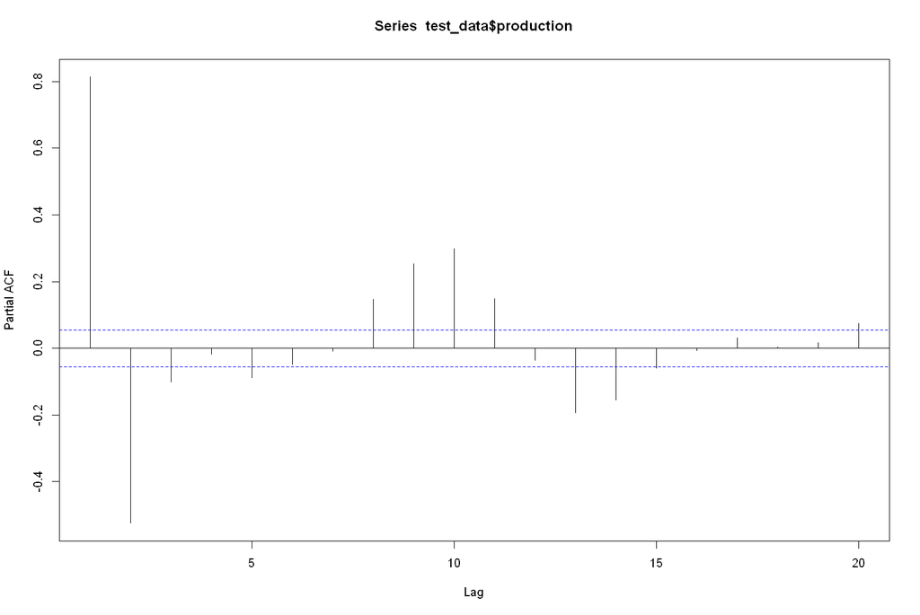

```r
pacf(test_data$production, lag.max=20)
```

Now we will add lag 10 values since the PACF peaks at 10. Note that this new model will be impractical for our task since we do not have the lagged 10 information in the forecasting setting (Lagged 10 value for 03.01.2024 12:00 is 02.01.2024 14:00 in our setting, which we do not know yet). Still, we will build this impractical model to see if it performs well.

## Second Approach : Linear Regression with Lasso Variables + Transformed Hour + Lag 10

```r
setDT(filtered_data)
filtered_data[, prod_lag_10 := shift(production, 10)]

filtered_data = as.data.frame(filtered_data)

# Filter out the columns you want to use as features
feature_columns <- setdiff(names(filtered_data), c('date','hour','production'))

# Create the predictor matrix X and response vector y
X <- filtered_data[, feature_columns, drop = FALSE]
y <- filtered_data$production

# Fit the linear regression model
model <- lm(production ~ ., data = filtered_data[, c(feature_columns, "production")])

# Print the summary of the model
summary(model)
```

```
Call:
lm(formula = production ~ ., data = filtered_data[, c(feature_columns,
    "production")])

Residuals:
   Min     1Q Median     3Q    Max
-8.957 -1.169  0.125  1.270  7.549

Coefficients:
                                      Estimate Std. Error t value Pr(>|t|)
(Intercept)                         -2.654e+01  1.915e+00 -13.862  < 2e-16 ***
csnow_surface_37.75_34.5             1.965e-01  1.785e-01   1.101 0.270825
csnow_surface_37.75_34.75           -1.709e-02  1.521e-01  -0.112 0.910519
csnow_surface_37.75_35.25           -1.533e-01  1.100e-01  -1.394 0.163500
csnow_surface_37.75_35.5             2.934e-01  1.549e-01   1.894 0.058234 .
csnow_surface_38.0_34.5             -4.662e-01  1.490e-01  -3.129 0.001758 **
csnow_surface_38.0_34.75            -1.208e-01  1.756e-01  -0.688 0.491647
csnow_surface_38.0_35.0              2.779e-01  1.541e-01   1.804 0.071305 .
csnow_surface_38.0_35.25            -1.156e-01  1.273e-01  -0.908 0.363960
csnow_surface_38.0_35.5              8.605e-02  1.456e-01   0.591 0.554418
csnow_surface_38.25_34.5             1.083e-01  1.724e-01   0.628 0.529855
csnow_surface_38.25_34.75            1.813e-01  2.089e-01   0.868 0.385477
csnow_surface_38.25_35.0            -1.381e-01  2.158e-01  -0.640 0.522380
csnow_surface_38.25_35.25            1.133e-01  2.141e-01   0.529 0.596764
csnow_surface_38.25_35.5            -8.734e-02  1.717e-01  -0.509 0.610939
csnow_surface_38.5_34.5              5.737e-01  1.996e-01   2.874 0.004062 **
csnow_surface_38.5_34.75             1.455e-01  2.085e-01   0.698 0.485396
csnow_surface_38.5_35.0             -3.893e-01  2.160e-01  -1.803 0.071473 .
csnow_surface_38.5_35.25            -3.744e-01  1.801e-01  -2.079 0.037616 *
csnow_surface_38.5_35.5              3.242e-01  1.245e-01   2.603 0.009253 **
csnow_surface_38.75_34.5            -1.755e-01  2.046e-01  -0.858 0.391079
csnow_surface_38.75_34.75           -1.381e-01  2.575e-01  -0.536 0.591743
csnow_surface_38.75_35.0            -2.311e-01  2.896e-01  -0.798 0.424746
csnow_surface_38.75_35.25           -1.858e-01  2.785e-01  -0.667 0.504701
csnow_surface_38.75_35.5            -2.725e-01  2.160e-01  -1.262 0.207147
dlwrf_surface_37.75_34.5            -2.206e-02  4.512e-03  -4.889 1.03e-06 ***
dlwrf_surface_37.75_34.75            9.350e-03  5.231e-03   1.788 0.073867 .
dlwrf_surface_37.75_35.0             5.242e-03  4.560e-03   1.150 0.250377
dlwrf_surface_37.75_35.25           -1.318e-02  3.292e-03  -4.004 6.27e-05 ***
dlwrf_surface_38.25_34.75           -1.369e-02  4.240e-03  -3.228 0.001250 **
```

[output cut: 139 more lines]

```
uswrf_top_of_atmosphere_38.75_34.5  -3.739e-03  8.886e-04  -4.208 2.60e-05 ***
uswrf_top_of_atmosphere_38.75_35.5   3.064e-02  4.994e-03   6.134 8.92e-10 ***
hour_transformed                     1.206e-01  4.601e-03  26.219  < 2e-16 ***
avg_temp_lag_1                      -4.636e-02  8.364e-03  -5.543 3.06e-08 ***
avg_temp_lag_2                      -5.051e-02  8.303e-03  -6.083 1.23e-09 ***
avg_temp_lag_3                      -1.598e-02  6.111e-03  -2.615 0.008932 **
max_production                       2.397e-01  1.920e-02  12.486  < 2e-16 ***
prod_lag_10                          1.406e-01  7.973e-03  17.633  < 2e-16 ***
---
Signif. codes:  0 '***' 0.001 '**' 0.01 '*' 0.05 '.' 0.1 ' ' 1

Residual standard error: 1.919 on 8929 degrees of freedom
  (10 observations deleted due to missingness)
Multiple R-squared:  0.7512,	Adjusted R-squared:  0.7463
F-statistic: 153.1 on 176 and 8929 DF,  p-value: < 2.2e-16
```

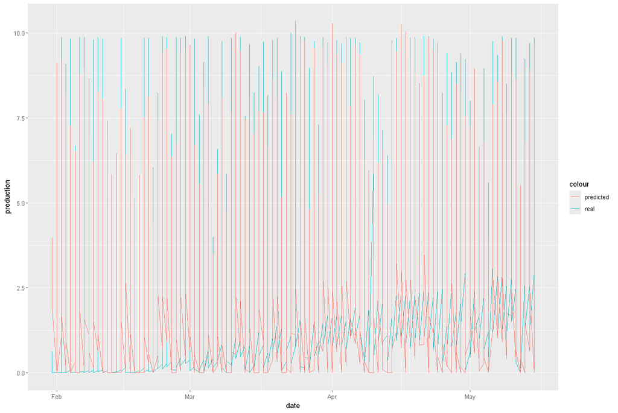

```
	Ljung-Box test

data:  Residuals
Q* = 597.35, df = 10, p-value < 2.2e-16

Model df: 0.   Total lags used: 10
```

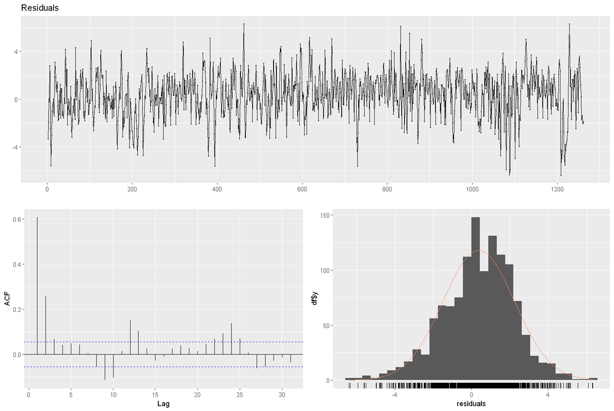

```r
second_model_evaluation <- test_data[, columns_to_keep, drop = FALSE]
setDT(second_model_evaluation)
second_model_evaluation[, prod_lag_10 := shift(production, 10)]
second_model_evaluation <- na.omit(second_model_evaluation)
second_model_evaluation[,predicted:=predict(model,second_model_evaluation)]
# Replace negative values with zero
second_model_evaluation[, predicted := ifelse(predicted < 0, 0, predicted)]
second_model_evaluation[,residual:=production-predicted]

ggplot(second_model_evaluation,aes(x=date)) + geom_line(aes(y=production,color='real')) + geom_line(aes(y=predicted,color='predicted'))
checkresiduals(second_model_evaluation$residual)
```

In the second model, it is visible that the underprediction problem is solved a little. However, this model is impractical as it uses lag 10 values.

```r
accu2 <- accu("2. Lasso(1sd) - LM_lag10 (IM)", second_model_evaluation$production, second_model_evaluation$predicted)
comparisons <- rbind(comparisons, accu2)
comparisons
```

A data.frame: 3 × 11

| model <chr> | n <int> | mean <dbl> | sd <dbl> | CV <dbl> | FBias <dbl> | MAPE <dbl> | RMSE <dbl> | MAD <dbl> | MADP <dbl> | WMAPE <dbl> |
| --- | --- | --- | --- | --- | --- | --- | --- | --- | --- | --- |
| 0. Baseline-LM | 1269 | 5.060165 | 3.389830 | 0.6699049 | 0.10482547 | 4469.314 | 1.993499 | 1.564115 | 0.3091036 | 0.3091036 |
| 1. Lasso(1sd)-LM | 1269 | 5.060165 | 3.389830 | 0.6699049 | 0.10880953 | 4058.146 | 1.994581 | 1.573241 | 0.3109070 | 0.3109070 |
| 2. Lasso(1sd) - LM_lag10 (IM) | 1262 | 5.044160 | 3.386026 | 0.6712765 | 0.07450837 | 4407.538 | 1.908707 | 1.505325 | 0.2984292 | 0.2984292 |

Since lag 10 is impractical, we will add lag 24 and lag 36 values instead, which will be practical for our forecasting setting.

## Third Approach : Linear Regression with Lasso Variables + Transformed Hour + Lag 24 + Lag 36

```r
filtered_data <- train_data[, columns_to_keep, drop = FALSE]

setDT(filtered_data)
filtered_data[, prod_lag_24 := shift(production, 24)]
filtered_data[, prod_lag_36 := shift(production, 36)]

filtered_data <- as.data.frame(filtered_data)

# Filter out the columns you want to use as features
feature_columns <- setdiff(names(filtered_data), c('date','hour','production'))

# Create the predictor matrix X and response vector y
X <- filtered_data[, feature_columns, drop = FALSE]
y <- filtered_data$production

# Fit the linear regression model
model <- lm(production ~ ., data = filtered_data[, c(feature_columns, "production")])

# Print the summary of the model
summary(model)
```

```
Call:
lm(formula = production ~ ., data = filtered_data[, c(feature_columns,
    "production")])

Residuals:
   Min     1Q Median     3Q    Max
-9.627 -1.103  0.111  1.204  7.898

Coefficients:
                                      Estimate Std. Error t value Pr(>|t|)
(Intercept)                         -1.913e+01  1.911e+00 -10.010  < 2e-16 ***
csnow_surface_37.75_34.5             1.994e-01  1.764e-01   1.130 0.258443
csnow_surface_37.75_34.75            1.767e-02  1.501e-01   0.118 0.906300
csnow_surface_37.75_35.25           -1.506e-01  1.086e-01  -1.386 0.165678
csnow_surface_37.75_35.5             1.854e-01  1.537e-01   1.206 0.227715
csnow_surface_38.0_34.5             -5.235e-01  1.469e-01  -3.563 0.000368 ***
csnow_surface_38.0_34.75            -1.261e-01  1.732e-01  -0.728 0.466495
csnow_surface_38.0_35.0              3.273e-01  1.521e-01   2.152 0.031455 *
csnow_surface_38.0_35.25            -1.265e-01  1.255e-01  -1.008 0.313622
csnow_surface_38.0_35.5             -3.204e-03  1.439e-01  -0.022 0.982231
csnow_surface_38.25_34.5             1.609e-01  1.701e-01   0.946 0.344175
csnow_surface_38.25_34.75            6.863e-02  2.063e-01   0.333 0.739371
csnow_surface_38.25_35.0            -7.409e-02  2.143e-01  -0.346 0.729560
csnow_surface_38.25_35.25            9.731e-02  2.135e-01   0.456 0.648482
csnow_surface_38.25_35.5            -5.453e-02  1.705e-01  -0.320 0.749082
csnow_surface_38.5_34.5              5.180e-01  1.998e-01   2.593 0.009518 **
csnow_surface_38.5_34.75             2.090e-01  2.060e-01   1.014 0.310395
csnow_surface_38.5_35.0             -5.201e-01  2.137e-01  -2.433 0.014980 *
csnow_surface_38.5_35.25            -2.897e-01  1.781e-01  -1.626 0.103889
csnow_surface_38.5_35.5              2.655e-01  1.230e-01   2.159 0.030858 *
csnow_surface_38.75_34.5            -1.801e-01  2.024e-01  -0.890 0.373712
csnow_surface_38.75_34.75           -2.006e-01  2.561e-01  -0.784 0.433346
csnow_surface_38.75_35.0            -7.825e-02  2.873e-01  -0.272 0.785324
csnow_surface_38.75_35.25           -2.288e-01  2.766e-01  -0.827 0.408102
csnow_surface_38.75_35.5            -3.076e-01  2.163e-01  -1.422 0.155103
dlwrf_surface_37.75_34.5            -2.517e-02  4.457e-03  -5.647 1.68e-08 ***
dlwrf_surface_37.75_34.75            1.519e-02  5.166e-03   2.940 0.003289 **
dlwrf_surface_37.75_35.0             3.965e-03  4.500e-03   0.881 0.378260
dlwrf_surface_37.75_35.25           -1.280e-02  3.252e-03  -3.937 8.30e-05 ***
dlwrf_surface_38.25_34.75           -1.030e-02  4.182e-03  -2.463 0.013800 *
```

[output cut: 140 more lines]

```
uswrf_top_of_atmosphere_38.75_35.5   3.203e-02  4.894e-03   6.545 6.29e-11 ***
hour_transformed                     7.435e-02  4.962e-03  14.985  < 2e-16 ***
avg_temp_lag_1                      -5.532e-02  8.212e-03  -6.736 1.73e-11 ***
avg_temp_lag_2                      -4.325e-02  8.196e-03  -5.276 1.35e-07 ***
avg_temp_lag_3                      -2.073e-02  6.001e-03  -3.454 0.000555 ***
max_production                       2.044e-01  1.903e-02  10.742  < 2e-16 ***
prod_lag_24                          1.618e-01  9.695e-03  16.693  < 2e-16 ***
prod_lag_36                          9.937e-02  9.510e-03  10.449  < 2e-16 ***
---
Signif. codes:  0 '***' 0.001 '**' 0.01 '*' 0.05 '.' 0.1 ' ' 1

Residual standard error: 1.892 on 8902 degrees of freedom
  (36 observations deleted due to missingness)
Multiple R-squared:  0.7579,	Adjusted R-squared:  0.7531
F-statistic: 157.5 on 177 and 8902 DF,  p-value: < 2.2e-16
```

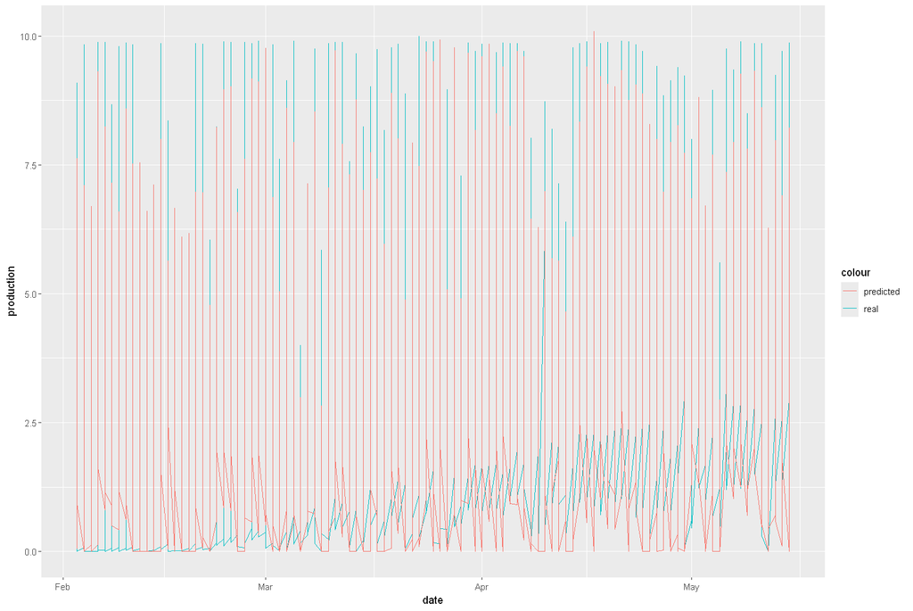

```
	Ljung-Box test

data:  Residuals
Q* = 667.49, df = 10, p-value < 2.2e-16

Model df: 0.   Total lags used: 10
```

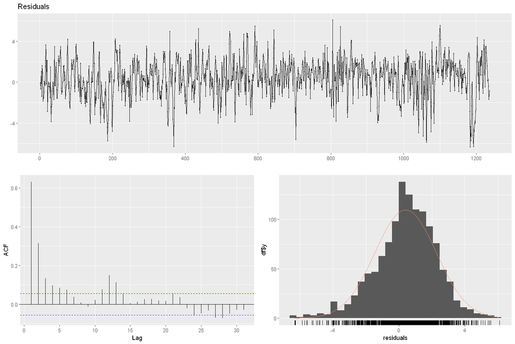

```r
data_path <- 'new_data_16may.csv'

test_data <- fread(data_path)
colnames(test_data) <- tolower(colnames(test_data))

cutoff_date <- as.IDate("2024-01-30")
test_data <- test_data[date > cutoff_date]

test_data <- na.omit(test_data)
test_data[, hour_transformed := -(hour - 12)^2]
test_data[, prod_lag_24 := shift(production, 24)]
test_data[, prod_lag_36 := shift(production, 36)]

test_data <- as.data.frame(test_data)

test_data$max_production <- sapply(1:nrow(test_data), function(i) {
  max_production <- ifelse(i <= 36, max(test_data$production[1:i]), max(test_data$production[(i - 35):i]))
  return(max_production)
})

tmp_surface_columns <- grep("^tmp_surface", names(test_data), value = TRUE)

# Compute the average of these columns for each row
test_data$avg_tmp <- rowMeans(test_data[, tmp_surface_columns], na.rm = TRUE)

setDT(test_data)
test_data[, avg_temp_lag_1 := shift(avg_tmp, 1)]
test_data[, avg_temp_lag_2 := shift(avg_tmp, 2)]
test_data[, avg_temp_lag_3 := shift(avg_tmp, 3)]
test_data <- na.omit(test_data)

third_model_evaluation <- copy(test_data)
third_model_evaluation[,predicted:=predict(model,third_model_evaluation)]
# Replace negative values with zero
third_model_evaluation[, predicted := ifelse(predicted < 0, 0, predicted)]
third_model_evaluation[,residual:=production-predicted]

ggplot(third_model_evaluation,aes(x=date)) + geom_line(aes(y=production,color='real')) + geom_line(aes(y=predicted,color='predicted'))
checkresiduals(third_model_evaluation$residual)
```